# An Introduction to ggplot2

*Professor Jessi Cisewski Kehe contributed to these lecture notes.*

## Overview

- These notes introduce the Lake Mendota case study and the **ggplot2** package for making plots
- We use data from the Lake Mendota freeze/thaw data set to introduce several types of plots
- Read the [chapter on Lake Mendota](https://bookdown.org/bret_larget/stat-240-case-studies/madison-lakes.html) from the Course Notes and Case Studies for background.
- The R Markdown file for this case study contains all of the code needed to replicate the analysis from lecture.
- However, lecture will skip quickly over the blocks of code that are not directly doing visualization.

## Lake Mendota

- Scientists have been recording the dates when Lake Mendota first closes with ice (at least half the surface is covered with ice) and opens (more than half the surface is liquid water) since the middle of the 1800s.
- In most winters, there is a single uninterrupted period of time from the first time the lake is closed in the winter to the first time it reopens in the spring.
  - Some winters have multiple intervals of closure
- The data set we are using summarizes the raw data with a single row for each winter from 1855–56 through last winter, 2021–22.
  - The variable `year1` is the first year of the given winter.
  - The variable `duration` is the total number of days that Lake Mendota was closed by ice in the given winter. (Note: the word “winter” used here specifies a single season spanning two consecutive calendar years and does not use the endpoints from the winter solstice to the spring equinox, for example.)
- We will first create graphs to examine the question, “How long does Lake Mendota freeze each winter?” with graphical exploration of the variable `duration`.
- Subsequently, we will examine the question, “How has the duration that Lake Mendota freezes each winter changed over time?” by exploring the relationship between `duration` and `year1`.

### Preliminaries

- For you to be able to run the code in this file, you need to put files in proper locations and set the working directory.
- Let `COURSE` represent your course directory.
1. If it does not yet exist, create the folder `COURSE/lectures`.
2. Create the sub-folder `COURSE/lecture/unit2-ggplot2/`
3. If it does not yet exist, create the folder `COURSE/data/`
4. Download the file `week2-ggplot2.Rmd` into the `unit2-ggplot2` sub-folder.
5. Download the file `lake-mendota-winters-2022.csv` into the `COURSE/data/` folder.

## Read the data

- The following R chunk has one line of code that will read in the data set.
- Along with the code I added many comments to explain what is happening.
- Each code chunk begins with three consecutive back ticks at the start of a line.
- The left brace `{` followed by the letter `r` means that the code should be interpreted as r code.
- The name `read-data` is the name of the chunk.
- Naming chunks is helpful when trying to find errors.
  - However, naming is optional; you can not include a name
  - *Be warned that attepting to knit an R Markdown file with duplicate chunk names results in an error.*
- Other knitr options could be set before the right brace `}`, but are not in this example.
- **Note that each R chunk in a file requires a unique name.**
- We will examine `read_csv()` and other functions to read in data later in the semester.
- All characters from the first `#` to the end of the line are comments

**Note: It is okay to just execute this code without worrying about the details. We will go over reading in data in more detail in a later unit of the course.**

```r
## `mendota` is a new object.
## The `=` assigns the loaded data set to the object name `mendota`.
## You will often see `<-' instead as the assignment operator.
##   I use `=` almost all the time, but `<-` is more common.

## read_csv() is a function in the tidyverse for reading in .csv files.
## There is a base R function named read.csv(). Use read_csv() instead.
## If you use read.csv(), character variables get changed to factors
##   and variable names might get changed.

## The argument to read_csv() is a path to the file with the data
## The '..' means go up a directory
## Use a '/' after a directory

## The result of the code below is to create a data frame named mendota
##   by reading in the data in the file.
### COURSE/data/ contains the data file
### COURSE/lectures/unit2-ggplot2/ is your working directory

mendota = read_csv("../../data/lake-mendota-winters-2022.csv")
```

### Checking the Data

- After reading in a data set, I often examine it by clicking on its name in the “Environment” tab in the upper right panel.
- The data will then be viewable in a tab in the upper left panel.
  - It is a good idea to see if the data looks like what you expected
- There are other commands to examine the structure of the data more carefully.
- The command `spec()` is part of the tidyverse and displays how each variable is specified after reading in.
  - R tries to guess the type of each variable
  - If wrong, you can read in the data again, specifying the type of each column
  - The output from `spec()` can be used to copy, paste, and edit to ensure each column’s data type is read in correctly.
  - For this data set, the guesses are all correct and no changes are required.
- **Note: once you have modified a data set, `spec()` may no longer work.**

```r
spec(mendota)
```

## Exploratory Data Analysis

- After reading in a new data set, it is a good idea to explore it, especially with visualization.
- Our data set has one row for each of 167 winters and 7 variables.
- Before creating a graph to visualize what the data has to say about or primary question about the change in the duration with which the lake is closed by ice over time, we use a variety of graphs to explore the individual variables.

## ggplot2

- The **tidyverse** package **ggplot2** is based on a *grammar of graphics* (what the **gg** in **ggplot2** stands for).
- Graphs are based on the following general principles:
  - there is a *mapping* between variables in a data set and various *aesthetics* of the plot
  - *geometries* determine how various aesthetics are represented in the plot
  - a complicated plot may be built by adding several *layers* to the plot
  - additional commands affect other aspects of the plot, such as scales, axes and their annotation, and so on
- The code in the **ggplot2** is a language which implements the grammar of graphics.
- The advantages of having a language for graphs include:
  - *Flexibility*: — the user has a rich language to create a variety of plots which may be customized in countless ways
  - *Reproducibility*: — Code to create graphs may be reused.
  - *Scalability*: — Code for a single graph may be used with iteration to create many graphs

## Plots

- We will first examine a number of plots for visualizing a single quantitative variable.
- Then, we will look at scatter plots to examine relationships between two quantitative variables.
- Additional variables may be shown on a scatter plot via color, shape, size, and other aesthetics, or by breaking a plot into multiple sub-plots by the groups in a categorical variable.

### One-variable Plots

- The variable *duration* is the number of days that the surface of Lake Mendota was at least 50% closed by ice each winter.
  - I may use the shorthand *frozen* to mean the same thing informally.
- This variable can be displayed with many different types of graphs.
- Every plot we make using the **ggplot2** package starts with the function `ggplot()` which takes the name of a data frame as its first argument.
- Then, new layers can be added to the plot.
- This almost always includes at least one geometric element, a function that begins with `geom_` followed by a descriptive name.
- Most plots will include multiple layers to add labels, modify previous layers, add more features to the plot, and so on.
- Note that the `+` sign must be at the end of each line, not the beginning of the line.
- (If not, R thinks you were done adding layers the first time there is not an `+` at the end.)

> Creating plots in R is typically an iterative process. Begin with a basic plot and see what it looks like. Then, refine the plot by building on additional layers. The code for complete plots that we show almost always are the result of this process of refinement. The following notes demonstrate this iteration.

#### Histograms

- A histogram is a bar plot for summarizing a **single quantitative variable**
  - The number line is divided into intervals which span the range of data values
  - Typically, each interval is the same width
  - The height of the each is proportional to the number of values in the corresponding interval
  - Some convention needs to be followed to determine where values on the boundary are counted
  - Unlike a bar plot of a categorical variable, there is no space between adjacent bars

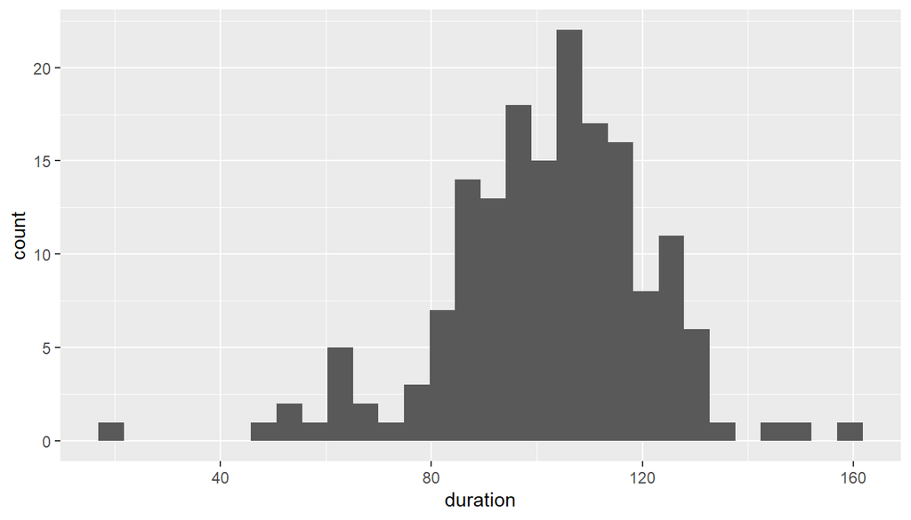

```r
ggplot(data = mendota, mapping = aes(x = duration)) +
  geom_histogram()
```

#### Naming Arguments

- We will use `ggplot()` very often and will soon memorize that the first argument is `data` and the second is `mapping`
  - We can leave off these argument names and create the same plot with

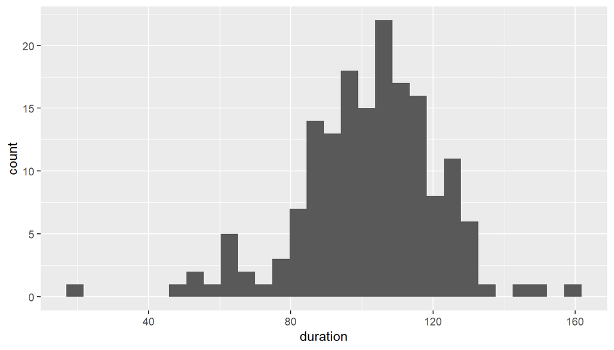

```r
ggplot(mendota, aes(x = duration)) +
  geom_histogram()
```

- The code chunk above contains a single command split over two lines to create the plot
- Each plot made with **ggplot2** typically consists of several *layers*
  - the commands for each later are separated by a `+` sign
  - it is good practice to make your code more easily readable to place each layer on a separate line
  - Each line except for the last ends with a `+`
  - R will continue to read additional lines to add to the command if the typed command so far is “left hanging” with a `+` meaning more is to come.
- The command `ggplot()` is always used to create a new plot.
  - the first argument to `ggplot()` is named `data` and is set to be the name of the data set which contains the data to be plotted
  - the second argument to `ggplot()` is named `mapping`, which describe a mapping between *variables* in the data set and aesthetics of the graph used to display the corresponding variable.
  - Aesthetics be things such as a location on the `x` or `y` axes, a color, a shape, a size, or more.
  - In this simple plot, the only variable is `duration` and it is displayed in the plot by locations on the x axis by setting `mapping` to be `aes(x = duration)`.
  - the value of `mapping` is always set using the function `aes()`.
- The next part of the command is `geom_histogram()` which determines which “geometry” is used to display the corresponding variables.
  - `geom_histogram()` creates a histogram

##### Refining the histogram

- There are may ways to improve the histogram:
  - The bin endpoints are not nice numbers
  - The bin widths are not nice numbers
  - It is hard to see where one bin ends and another begins; different colors for the boundary and interior would help
  - Axis labels use internal variable names, not names which would be easier for others to read and understand
  - There is no title to the plot
- The next histogram changes:
  - the labels with `ggtitle()`, `xlab()`, and `ylab()`
  - the widths of the bars with the `binwidth` argument
  - the boundaries where the bars are set with the `boundary` argument
  - the color of the bar interiors with the `fill` argument
  - the color of the bar outlines with the `color` argument
- Note: the arguments `fill`, `color`, `binwidth`, and `boundary` here **are not contained within a call to `aes()`**.
  - These are aesthetics or characteristics of the plot, but they are not mapped to variables in the data set.
  - There may be other plots where we want the color or fill color to change according to different values of a variable, but here, these designations set characteristics for the entire plot.

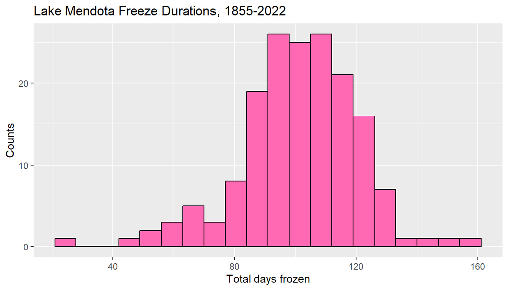

```r
ggplot(mendota, aes(x = duration)) +
  geom_histogram(fill = "hotpink",
                 color = "black",
                 binwidth = 7,
                 boundary = 0) +
  xlab("Total days frozen") +
  ylab("Counts") +
  ggtitle("Lake Mendota Freeze Durations, 1855-2022")
```

##### Bin endpoints

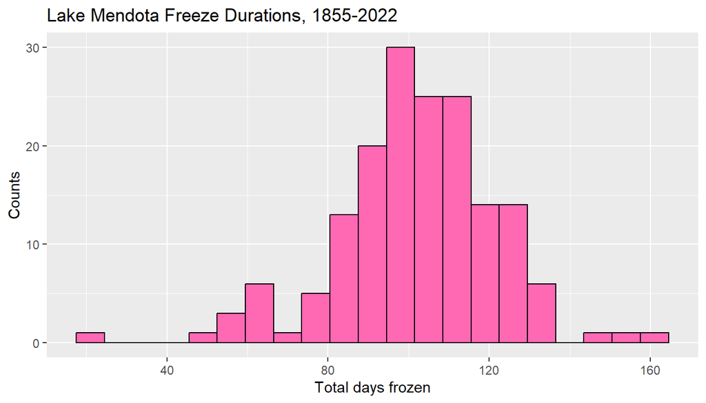

```r
ggplot(mendota, aes(x = duration)) +
  geom_histogram(fill = "hotpink",
                 color = "black",
                 binwidth = 7,
                 center = 0) +
  xlab("Total days frozen") +
  ylab("Counts") +
  ggtitle("Lake Mendota Freeze Durations, 1855-2022")
```

##### Where to specify the data and aesthetics

- Any data and aesthetics mapping set within `ggplot()` carry over to all additional layers (some of which will ignore them)
- A layer can modify these by using `data` or `mapping` arguments in the command to create the layer.

##### A histogram with too few bins

- Selecting appropriate settings for the bins is not easy and it can dramatically affect the appearance of the histogram.
- The histogram below has too few bins (the bins were set to be too wide) and we cannot evaluate the shape of the distribution because it has been over-summarized.

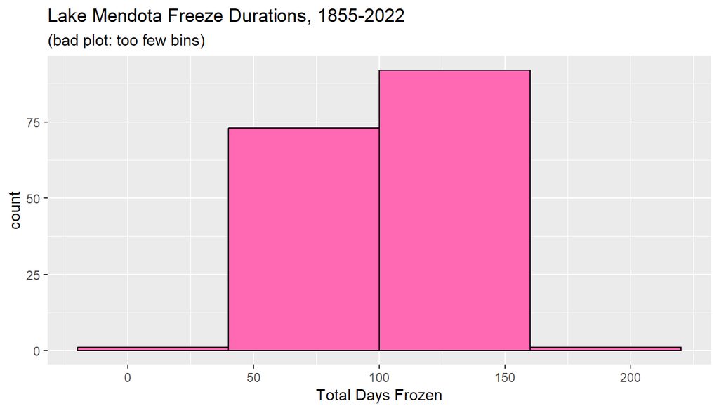

```r
ggplot(mendota, aes(x = duration)) +
  geom_histogram(center = 70, binwidth = 60,
                 fill='hotpink', color='black') +
  xlab("Total Days Frozen") +
  ggtitle("Lake Mendota Freeze Durations, 1855-2022",
          subtitle = "(bad plot: too few bins)")
```

##### A histogram with too many bins

- We can also error in the direction of too many bins!
- In the histogram below, the bin width is too small and the histogram contains many spikes.
- Again we cannot easily evaluate the overall shape of the distribution because there is too much detail and not enough summarization.

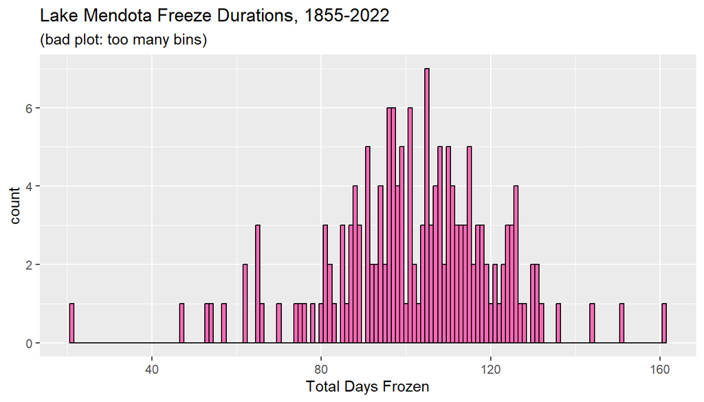

```r
ggplot(mendota, aes(x=duration)) +
  geom_histogram(center=70, binwidth=1,
                 fill='hotpink', color='black') +
  xlab("Total Days Frozen") +
  ggtitle("Lake Mendota Freeze Durations, 1855-2022",
          subtitle = "(bad plot: too many bins)")
```

##### Another decent histogram

- There is not a single best choice of bin endpoints.
- The first plot used a width of 7 days, or one week.
- Alternatively, we may have used a round number like 10 and centered on a nice round number like 100.

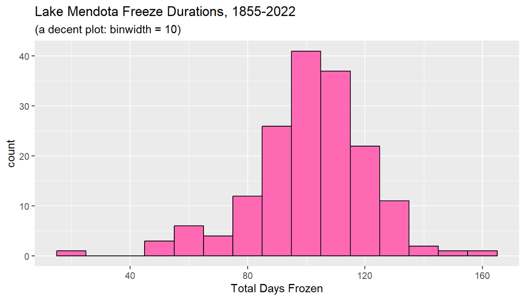

```r
ggplot(mendota, aes(x=duration)) +
  geom_histogram(center=100, binwidth=10,
                 fill='hotpink', color='black') +
  xlab("Total Days Frozen") +
  ggtitle("Lake Mendota Freeze Durations, 1855-2022",
          subtitle = "(a decent plot: binwidth = 10)")
```

> There is rarely a single best choice of bins in a histogram, but there are many ways to make a poor choice.

#### Density Plots

- A histogram is just one example of a “geom” to display a single quantitative variable
- An alternative is a density plot which lessens the visual effects due to arbitrary choices to determine bin endpoints.
- A density plot may be thought of as an average of a lot of histograms
- Rather than displaying counts on the y axis, instead, the scale is modified so that the total area under the curve is one
- A density plot can be thought of as a *smoothed histogram*.
- We can display the same data using density plot using `geom_density().`

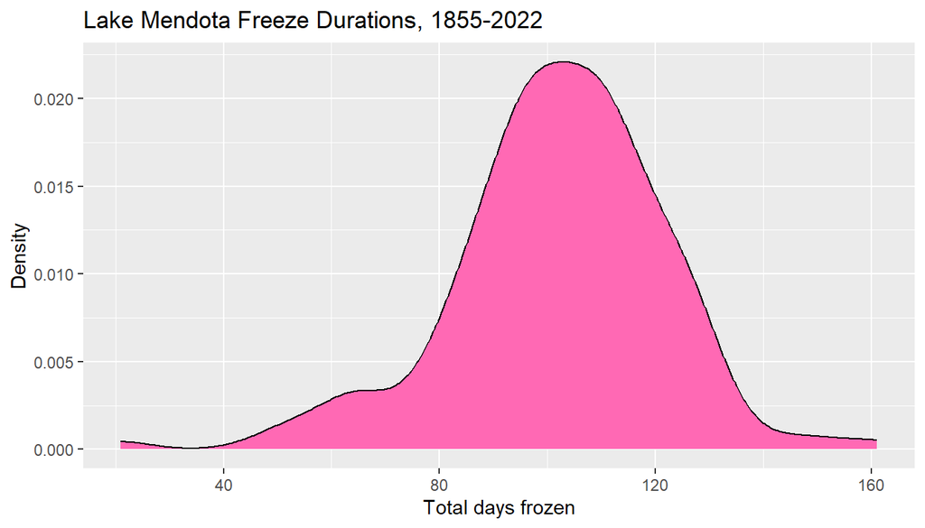

```r
ggplot(mendota) +
  geom_density(aes(x=duration),
               fill="hotpink",
               color="black") +
  xlab("Total days frozen") +
  ylab("Density") +
  ggtitle("Lake Mendota Freeze Durations, 1855-2022")
```

- In a density plot, the “Count” on the y axis is replaced by “Density”
- The numerical values are scaled so that the total area under the curve is equal to one.
- Density plots smooth away the harsh transitions of a histogram, but lose the capability to display the raw data counts.
  - From a histogram with counts, we know how many observations are in each interval and can determine the total number of observations in the data
  - A density plot only shows relative amounts of data and loses this sample size information.
- Histograms and density plots are the most common ways to display the distribution of single quantitative variables, but others exist.
  - See the **ggplot2** cheat sheet for more examples.

##### Interpreting a Density Plot

- A density plot provides information about what proportion of the observations are in each interval, approximately
- For example, the area in the previous plot to the left of 80 looks to be, maybe, about 10% of the total.
- I add a vertical line at 80 to help visualize this.

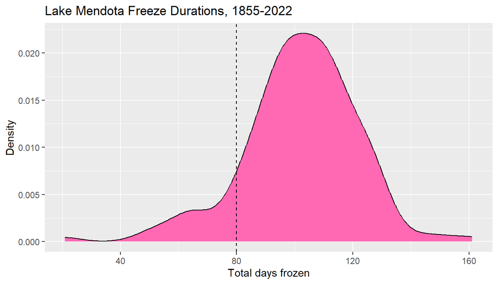

```r
ggplot(mendota) +
  geom_density(aes(x=duration),
               fill="hotpink",
               color="black") +
  geom_vline(xintercept = 80, linetype = "dashed") +
  xlab("Total days frozen") +
  ylab("Density") +
  ggtitle("Lake Mendota Freeze Durations, 1855-2022")
```

- We can count the actual number of `duration` values which are 80 or below.
- In fact, exactly 17 of the 167 durations from the winters from 1855-56 to 2021-22, or about 10%, are 80 days or fewer.

#### Boxplots

- A boxplot is a graphical depiction of some key quantiles of a distribution of numerical values.
  - The minimum (smallest value)
  - The first quartile (25th percentile or 0.25 quantile)
  - The median (the middle value / 50th percentile / 0.5 quantile)
  - The third quartile (75th percentile or 0.75 quantile)
  - The maximum
- Typical boxplots often also identify potential outliers which are extreme values far enough below the first quartile or above the third quartile.
- This code chunk creates a vertical boxplot of `duration` by mapping it to the aesthetic `y`.
- See what happens if we use `x` instead?

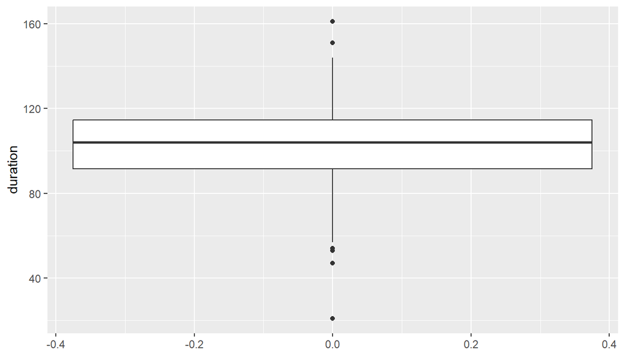

```r
ggplot(mendota, aes(y = duration)) +
  geom_boxplot()
```

- The box outlines the middle 50% of the observations
  - the bottom of the box (i.e., the lower hinge) gives the 25th percentile (the first quartile, Q1)
  - the middle bar give the median (the 50th percentile)
  - the top of the box (i.e., the upper hinge) gives the 75th percentile (the third quartile, Q3)
- The lower vertical line (i.e., the lower whisker) reaches down to the minimum value of the observations, but will not drop below Q1 - 1.5 x IQR, where IQR = Q3 - Q1 is the inter-quartile range.
- Similarly, the higher vertical line (i.e., the upper whisker) reaches up to the maximum value of the observations, but will not go above Q3 + 1.5 x IQR.
- Any points plotted below or above the vertical lines indicate observations that are below or above the noted ranges. These points may be considered potential outliers.
- The number line on the x axis is meaningless and arbitrary.

##### Changing the orientation

- Often, when using a box plot for a single variable, I prefer viewing the distribution horizontally.
- To do so, just change the aesthetic to which `duration` is mapped from `y` to `x`.

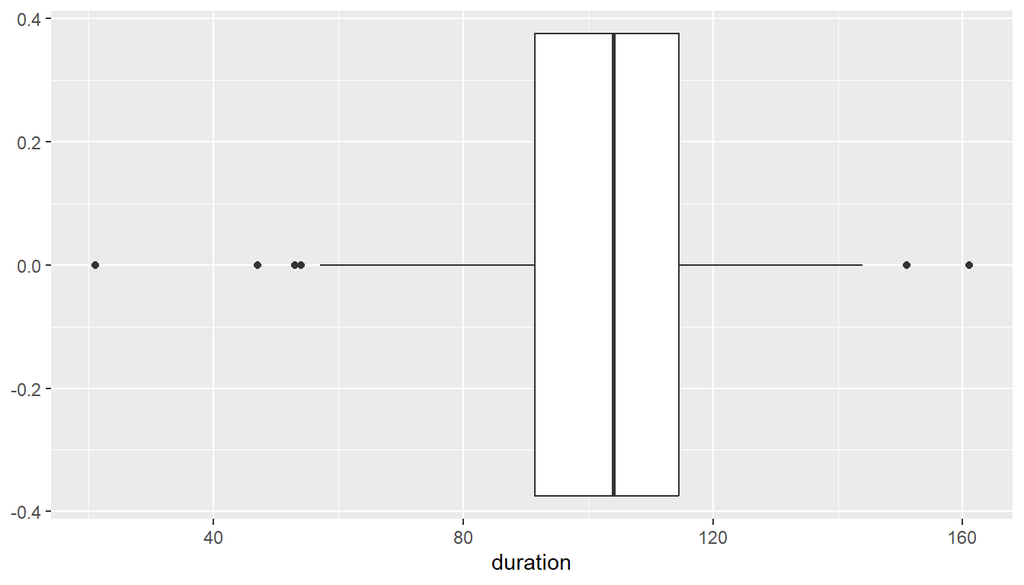

```r
ggplot(mendota, aes(x = duration)) +
  geom_boxplot()
```

#### Side-by-side box plots

- We rarely use box plots to summarize a single variable as the graphical summary from a histogram or density plot is so much more informative.
- However, boxplots can be very useful when we wish to compare multiple distributions to each other on the same numerical scale
- For example, the variable `decade` partitions each year into the decade associated with its first year.
- This plot shows side by side box plots to help see how freeze durations have changed over time.
- Each boxplot is from 10 or fewer data points
- The `x` variable is set to `as.character(decade)` so that `decade` is treated as categorical and not numerical.

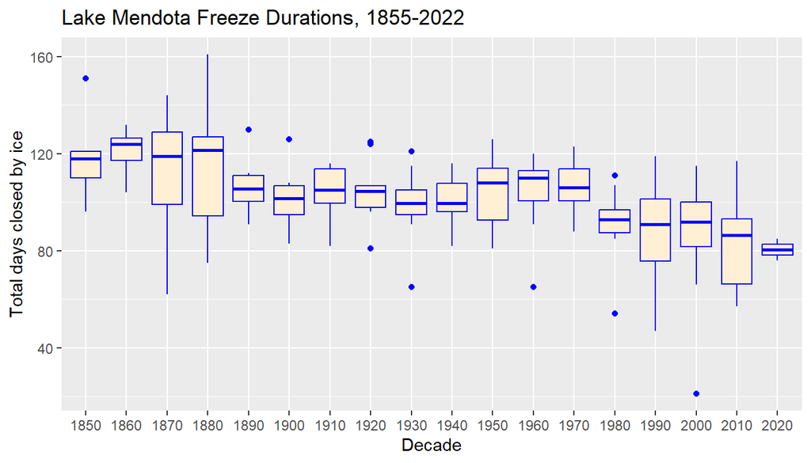

```r
ggplot(mendota, aes(x = as.character(decade), y = duration)) +
  geom_boxplot(fill = "papayawhip",
               color = "blue") +
  ylab("Total days closed by ice") +
  xlab("Decade") +
  ggtitle("Lake Mendota Freeze Durations, 1855-2022")
```

- We see that in the 1800s, a typical freeze duration was nearly 120 days whereas in more recent decades, a typical duration has decreased to under 90 days.

## Lake Mendota Graphs – days frozen vs. time

- We wish to create a graph to examine the relationship between the duration which Lake Mendota is frozen versus time
- We may expect there to be a decrease over time as a result of global warming causing the average temperature in Madison to be trending warmer in the winter.

### Question 1

> How do the total number of days that Lake Mendota is closed with ice vary over time?

### Two-variable Plots

- Earlier, we took the numerical variable `year1` and turned it into a categorical variable `decade`, collecting the observations by decade, and plotted the data with side-by-side box plots.
- We did this primarily to demonstrate how to create side-by-side boxplots.
- However, there is a better way:
  - Examine the relationship between `year1` and `duration` directly with an augmented scatter plot.

#### Scatter Plots

- A scatter plot summarizes two numerical variables by associating one with the x axis and the other with the y axis and plotting points.
- This R chunk displays a cloud of data points with `year1` specifying the location on the x axis and `duration` the location on the y axis.

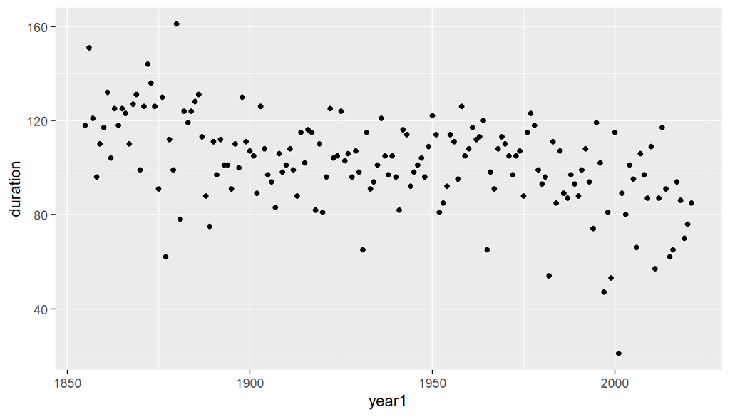

```r
ggplot(mendota, aes(x = year1, y = duration)) +
  geom_point()
```

##### Observations

- We can kind of see a decreasing pattern over time, but it is difficult to trace the year-to-year changes and difficult to see the general pattern as clearly as possible separate from the year-to-year noise
- When one variable is time, it is often useful to use a “trace plot” instead of a scatter plot by changing the geometry from plotting individual points (using `geom_point()`) to line segments which connect consecutive points (using `geom_line()`).

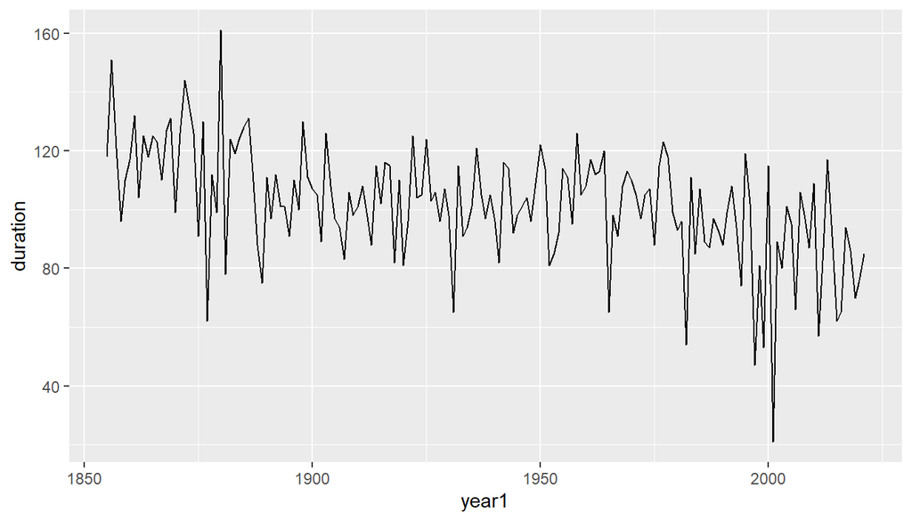

```r
ggplot(mendota, aes(x = year1, y = duration)) +
  geom_line()
```

- This graph makes it easier to see that there is a decreasing trend, but that the actual pattern of decrease is quite noisy with substantial year-to-year variation.
- Another geometry, `geom_smooth()`, greatly reduces the noise and replaces the actual data values with a smooth curve.

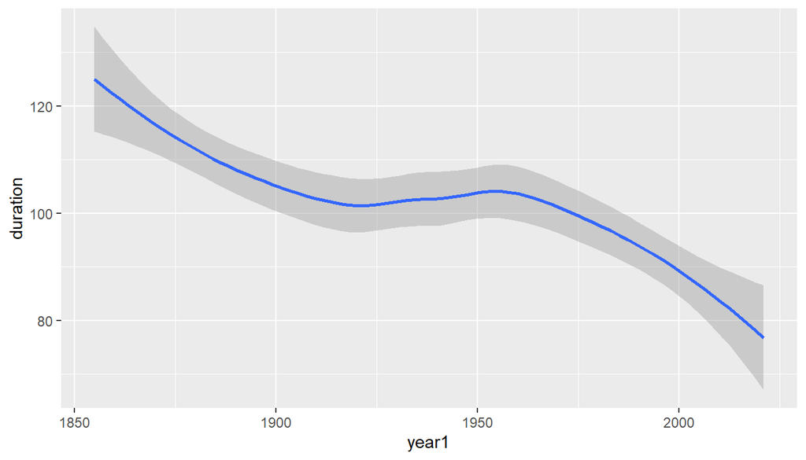

```r
ggplot(mendota, aes(x = year1, y = duration)) +
  geom_smooth()
```

- The default graph produced with `geom_smooth()` draws a ribbon to represent uncertainty in the true value of the estimated trend line.
- We can discard this ribbon by setting the argument `se` (short for *standard error* which we will see later in the course) to be `FALSE`.

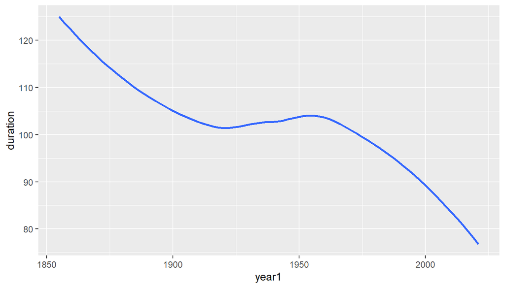

```r
ggplot(mendota, aes(x = year1, y = duration)) +
  geom_smooth(se = FALSE)
```

- After suppressing the year-to-year noise, we see a summarized pattern where the duration with which Lake Mendota has remained closed by ice in a typical year has decreased from over 120 days in 1850 to under 80 days at present.
  - There was a steady decline from 1850 to about 1920, followed by about 30–40 years of with a slight increase on average, followed by a decline at an even faster rate from about 1960 to the present.
  - Perhaps the rate of decrease is becoming steeper.

#### Scatter Plot with a Trend Line Added

- There is no reason to select only one of the previous plots.
- A better graphical display can be obtained by layering multiple pieces of the previous graphs together.

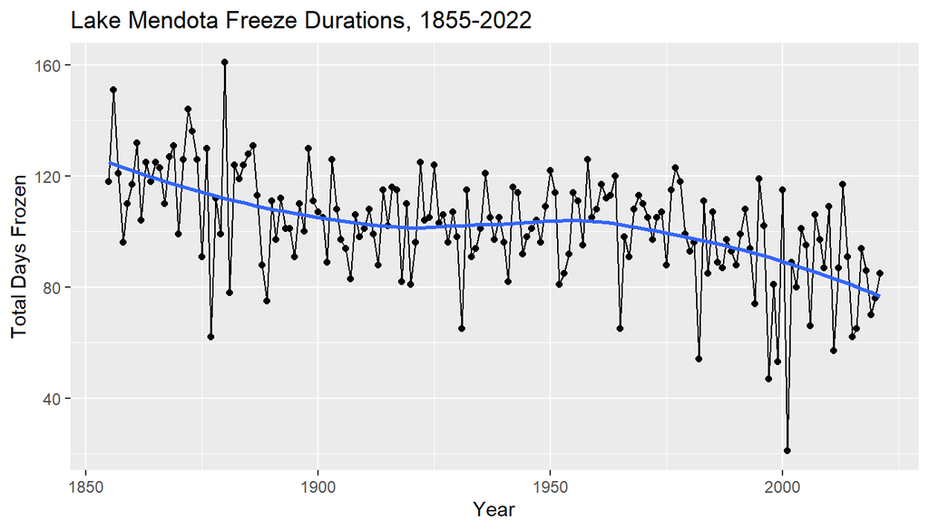

```r
## note setting the aesthetics here in ggplot()
## otherwise, we would need to set the in geom_point(), geom_line(), and geom_smooth() each separately
ggplot(mendota, aes(x=year1, y=duration)) +
  geom_point() +
  geom_line() +
  geom_smooth(se=FALSE) +
  xlab("Year") +
  ylab("Total Days Frozen") +
  ggtitle("Lake Mendota Freeze Durations, 1855-2022")
```

### Observations

- There does appear to be a decrease in the freeze durations over time
- Informally, we might interpret the blue curve as a description of what the climate is doing
  - ignoring year-to-year fluctuations, the typical average duration for Lake Mendota to freeze over the winter has decreased from about 120 days (or four months) in the mid 1850s to under 80 days (about 11 weeks) currently.
- The variation of the points around the blue curve may be interpreted as random “noise” caused by differences in the weather at key parts of the fall and winter seasons from year to year.

#### A basic model

- Later in the semester, we will investigate proposing, fitting, and interpreting statistical models to study this relationship.
- We might think of the blue curve as an estimate of some underlying “true” relationship between the expected duration of time which Lake Mendota is closed by ice versus time which is a feature of the climate as it changes over time.
- The actual data represents this trend with the “noise” of random variation due to the weather in each year.
- A statistical model describes the observed data as the sum of a mean trend over time plus random noise for each observation.
- Later in the semester we will explore these ideas of statistical modeling and statistical inference in more detail.

### Question 2

> In a typical year, how much does the actual duration for which Lake Mendota is frozen (the surface is at least 50% covered by ice) vary from its predicted value? (How far apart are the black points and the blue curve, typically, in a given year)?
- To address this question, we need to augment the data set by adding a numerical variable which includes this calculation.
- A block of code we suppress in these notes accomplishes this to create a variable named `residual` which we can examine.
- Here are the first few rows of the augmented data set.
  - The `width = Inf` argument makes sure that all variables are included in the printed output.

```r
print(mendota, width = Inf)
```

```
## # A tibble: 167 × 9
##    winter  year1 intervals duration first_freeze last_thaw  decade fitted
##    <chr>   <dbl>     <dbl>    <dbl> <date>       <date>      <dbl>  <dbl>
##  1 1855-56  1855         1      118 1855-12-18   1856-04-14   1850   125.
##  2 1856-57  1856         1      151 1856-12-06   1857-05-06   1850   124.
##  3 1857-58  1857         1      121 1857-11-25   1858-03-26   1850   124.
##  4 1858-59  1858         1       96 1858-12-08   1859-03-14   1850   123.
##  5 1859-60  1859         1      110 1859-12-07   1860-03-26   1850   123.
##  6 1860-61  1860         1      117 1860-12-14   1861-04-10   1860   122.
##  7 1861-62  1861         1      132 1861-12-02   1862-04-13   1860   121.
##  8 1862-63  1862         1      104 1862-12-26   1863-04-09   1860   121.
##  9 1863-64  1863         1      125 1863-12-18   1864-04-21   1860   120.
## 10 1864-65  1864         1      118 1864-12-08   1865-04-05   1860   120.
##    residual
##       <dbl>
##  1    -7.00
##  2    26.6
##  3    -2.77
##  4   -27.2
##  5   -12.6
##  6    -4.99
##  7    10.6
##  8   -16.8
##  9     4.71
## 10    -1.73
## # … with 157 more rows
```

- In the first recorded winter of 1855–56, Lake Mendota was closed by ice for 118 days, but the trend curve in the same winter predicted 125 days. The residual is the difference, $-7 = 118 - 125$.
- Let’s create a density plot to visualize the distribution of all of the residuals.

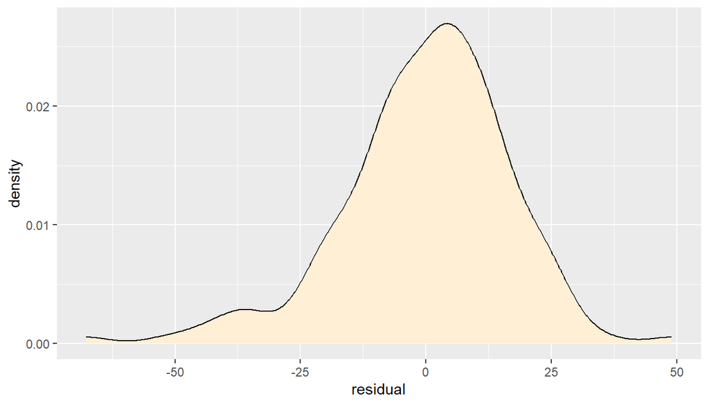

```r
ggplot(mendota, aes(x = residual)) +
  geom_density(fill = "papayawhip")
```

- From this plot, we see that the distribution of year to year annual variation around the trend curve is approximately bell-shaped and centered at zero, but there is some slight left skewness (the left tail is bigger than the right tail).

> It is more common for a winter where the actual duration for which Lake Mendota is closed by ice is extremely lower than typical than a winter where it is abnormally longer than typical.
- The scale of the plot indicates that it is not at all unusual for the actual duration Lake Mendota is closed by ice to differ from the trend line by about 2 to 3 weeks in either direction.
- Most of the area under the curve is between about $-21$ days and $+21$ days, but there are a fair number of years which exceed these typical values.
- We could also examine the distribution of the residuals around the smooth curve with a box plot.

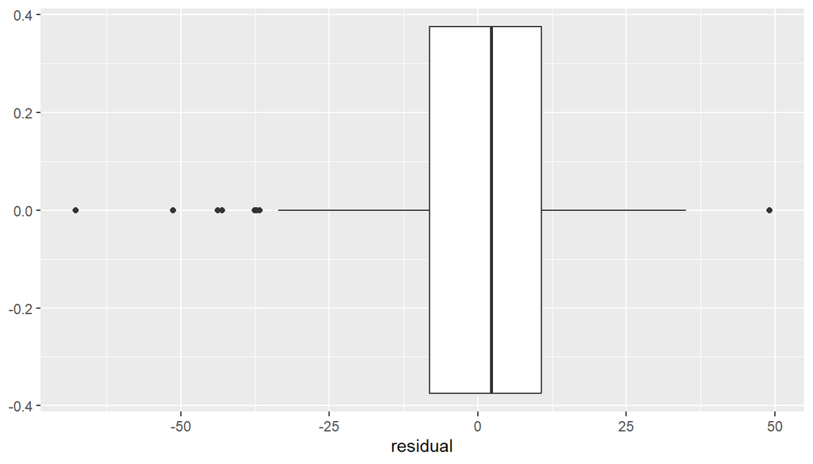

```r
ggplot(mendota, aes(x = residual)) +
  geom_boxplot()
```

#### Mean and Standard Deviation

- When we learn about **dplyr** next week, we will develop some skills for summarizing data.
- A common way to summarize a collection of numbers is the *mean*, or the sum divided by the number of values.

$$\bar{x} = \frac{\sum_{x=1}^n x_i}{n}$$

- The *mean* (like the median) is a way to measure the center of a distribution, but they measure the center in different ways.
  - The mean is the *balancing point*.
  - The median is the *middle number*, half the values are at least as big and half are at least as small.
- The *standard deviation* measures how far apart a distribution of numbers are from one another.

$$s = \sqrt{ \frac{\sum_{x=1}^n (x_i - \bar{x})^2}{n-1} }$$

- The standard deviation is almost the square root of the mean squared deviations from the mean (almost because we divide by $n-1$ and not $n$).
- The standard deviation may often be interpreted as about the size of a typical deviation of an individual value from the mean.
- A *quantile* is a value which indicates a location in a distribution by indicating the proportion of values below (and above).
  - The median is the 0.50 quantile because half the value are the median or below
  - 100 times a quantile is referred to as a *percentile*.

#### Numerical summaries of the residuals

- A block of code suppressed in these notes calculates the mean, standard deviation, median, and several other quantiles of the distribution of the residuals.

```
## # A tibble: 1 × 8
##      mean median    sd   q10   q25   q50   q75   q90
##     <dbl>  <dbl> <dbl> <dbl> <dbl> <dbl> <dbl> <dbl>
## 1 -0.0577   2.22  16.7 -20.2 -8.16  2.22  10.7  18.8
```

- The mean of the distribution is close to zero.
- The median is about 2 days above zero.
- The standard deviation is 16.7 days, or about 2.4 weeks.

### Augmenting a plot with lines

- Sometimes it is helpful to add vertical lines to a plot to help identify specific locations on the x axis.
- This next chunk of code adds vertical lines that are 1, 2, and 3 standard deviation below and above the center of zero.

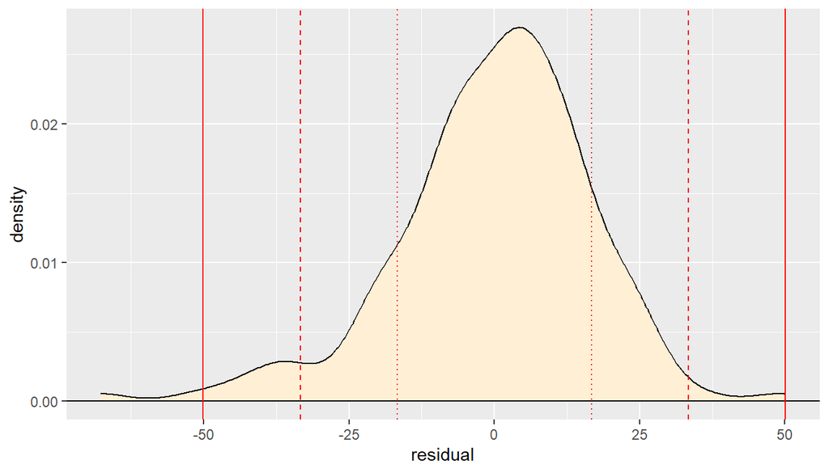

```r
ggplot(mendota, aes(x = residual)) +
  geom_density(fill = "papayawhip") +
  geom_hline(yintercept = 0) +
  geom_vline(xintercept = c(-1,1)*16.7,
             color = "red", linetype = "dotted") +
  geom_vline(xintercept = c(-1,1)*2*16.7,
             color = "red", linetype = "dashed") +
  geom_vline(xintercept = c(-1,1)*3*16.7,
             color = "red", linetype = "solid")
```

- Symmetric bell-shaped solutions have the following approximate features (which are exactly true for an ideal normal distribution).
  - About 68% of the data is within one standard deviation of the mean.
  - About 95% of the observations are within two standard deviations of the mean
  - Nearly all of the observations are within three standard deviations of the mean
- Here, our density is not perfectly ideal and there are likely a bit fewer than 95% of the values within two standard deviations with extras in the left tail of the distribution

### Axis Labels and Plot Titles

- Previous examples have shown how to use the commands `xlab()` and `ylab()` to modify the displayed axis labels in a plot.
- We have also shown how to use `ggtitle()` to add a title to a plot.
- When working interactively, it is fine to not worry about axis labels and plot titles: you know what the variables are and know what you are examining in the plot.
- However, when making a plot to present to someone else (or for yourself to look at in the future), it is best practice to create meaningful axis labels and a plot title.
  - **In particular, when creating plots for homework assignments, projects, or as part of a take-home exam, do make sure to create informative axis labels and plot titles.**
- The arguments to `xlab()` and `ylab()` are almost always just a simple text string, such as we have seen.
- You can suppress a label with the empty string `""`.
- In more advanced code we will not cover, you can:
  - modify font size and type
  - use greek symbols or mathematical notation
  - create labels which include variables that can change if the values do
- Usually, plot titles made with `ggtitle()` are also just a simple string as an argument.
- The example below also uses the argument `subtitle` to add a second line to the displayed title in a smaller font.
  - This is especially useful when an informative title is too long for a single line.

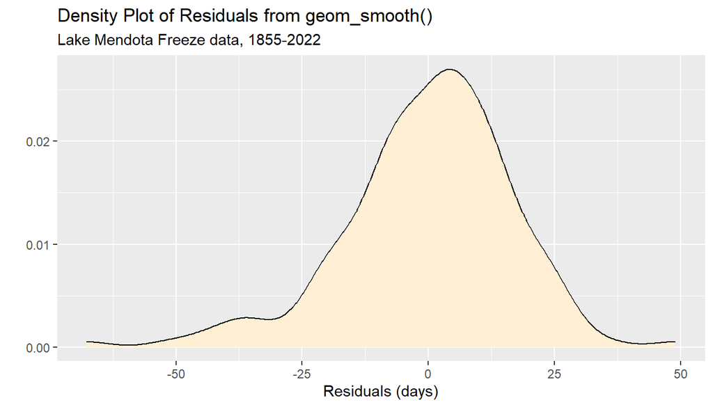

```r
ggplot(mendota, aes(x = residual)) +
  geom_density(fill = "papayawhip") +
  xlab("Residuals (days)") +
  ylab("") +
  ggtitle("Density Plot of Residuals from geom_smooth()",
          subtitle = "Lake Mendota Freeze data, 1855-2022")
```

### Question 3

> When in the winter does Lake Mendota typically close with ice the first time?
- To answer this question graphically, I decided to create a new variable `ff_period` which categorizes the date of the first freeze into a half-month time period, from “Nov 16-30” through “Jan 16-31”
  - (the earliest date Lake Mendota closed with ice was November 23 during the winter of 1880-81 and the latest date Lake Mendota closed with ice was January 30 during the winter of 1931-32).
- The variable `ff_after_june_30` counts the number of days after June 30 the Lake Mendota first freezes in a given winter.
  - For example, November 30 is 153 days after June 30 each year.
- A suppressed block of code adds the variables `ff_after_june_30` and `ff_period` to the `mendota` data set.
- A new data frame `mendota_sum` contains counts of the number of winters in each period.
- Here are the first few rows of selected columns of each data set.

```
## # A tibble: 5 × 4
##   winter  duration first_freeze ff_period
##   <chr>      <dbl> <date>       <fct>
## 1 1855-56      118 1855-12-18   Dec 16-31
## 2 1856-57      151 1856-12-06   Dec 1-15
## 3 1857-58      121 1857-11-25   Nov 16-30
## 4 1858-59       96 1858-12-08   Dec 1-15
## 5 1859-60      110 1859-12-07   Dec 1-15
```

```
## # A tibble: 5 × 2
##   ff_period     n
##   <fct>     <int>
## 1 Nov 16-30     4
## 2 Dec 1-15     47
## 3 Dec 16-31    80
## 4 Jan 1-15     34
## 5 Jan 16-30     2
```

### Bar Graphs

- A bar graph is a common way to display the counts of a categorical variable.
- The **ggplot2** command `geom_bar()` is used to create bar graphs from a data set where the heights of the bars need t be calculated.
- In contrast, the **ggplot2** command `geom_col()` is used when there is one column for the categorical variable and another column which contains the heights of the bars.

#### geom_bar()

- This code creates a bar graph from the `ff_period` variable of the `mendota` data set.
  - The bar heights are calculated by counting the number of winters in each category.

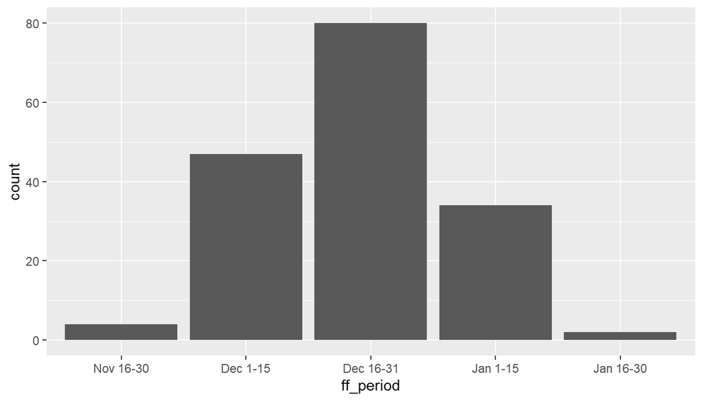

```r
ggplot(mendota, aes(x = ff_period)) +
  geom_bar()
```

- We can add layers to improve the appearance.

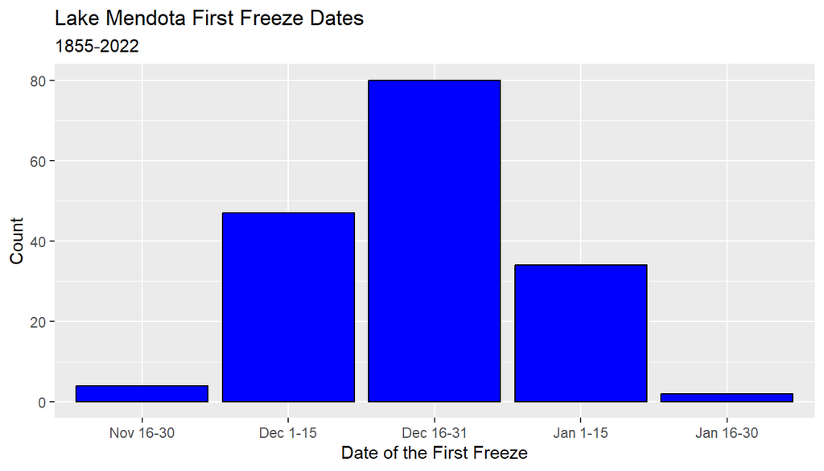

```r
ggplot(mendota, aes(x = ff_period)) +
  geom_bar(color = "black", fill = "blue") +
  xlab("Date of the First Freeze") +
  ylab("Count") +
  ggtitle("Lake Mendota First Freeze Dates",
          subtitle = "1855-2022")
```

#### geom_col()

- Here a table with the summary counts

```r
mendota_sum
```

```
## # A tibble: 5 × 2
##   ff_period     n
##   <fct>     <int>
## 1 Nov 16-30     4
## 2 Dec 1-15     47
## 3 Dec 16-31    80
## 4 Jan 1-15     34
## 5 Jan 16-30     2
```

- Use `geom_col()` and set both `x` and `y` aesthetics.

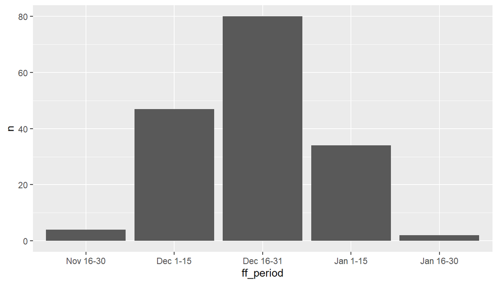

```r
ggplot(mendota_sum, aes(x = ff_period, y = n)) +
  geom_col()
```

- Again, make the graph better for presentation.

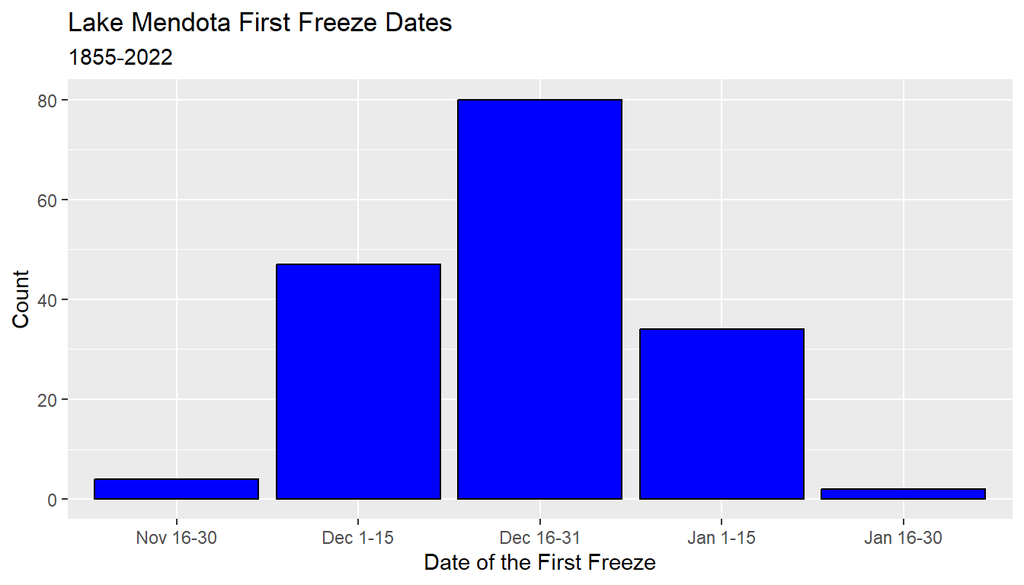

```r
ggplot(mendota_sum, aes(x = ff_period, y = n)) +
  geom_col(color = "black", fill = "blue") +
  xlab("Date of the First Freeze") +
  ylab("Count") +
  ggtitle("Lake Mendota First Freeze Dates",
          subtitle = "1855-2022")
```

### Facets

- Facets are a way to partition a data set according to one or two categorical variables
- Each part of the data is displayed in its own panel (facet) of a common plot.
- Typically, the axes are consistent for all facets, but this can be relaxed.
- To demonstrate faceting, we add a new categorical variable `period50` to the `mendota` data set which divides the years into 50-year periods.
- This block of code is also suppressed in these notes.

#### facet_wrap()

- The command `facet_wrap()` partitions the data by one or more categorical variables
- Each different combination of values receives it own facet.
- The computer decides how to break the collection of facets into separate rows
- Use the function `vars()` to list the variable on which to facet.
  - The old-style syntax used a formula, such as `~period50` to specify the faceting variable.
  - I am working on forgetting this old syntax
- Here, the four facets are broken into two rows of two

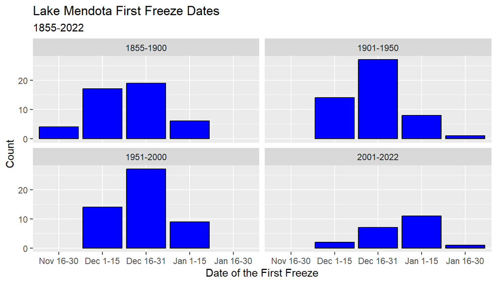

```r
ggplot(mendota, aes(x = ff_period)) +
  geom_bar(color = "black", fill = "blue") +
  xlab("Date of the First Freeze") +
  ylab("Count") +
  ggtitle("Lake Mendota First Freeze Dates",
          subtitle = "1855-2022") +
  facet_wrap(vars(period50))
```

- You can see more examples at the [tidyverse reference page for `facet_wrap()`](https://ggplot2.tidyverse.org/reference/facet_wrap.html)

#### facet_grid()

- The command `facet_grid()` is used when you want to organize the rows and/or columns of the facets by one or more variables.
- This example forces the facets to use a different row for each value of `period50`.

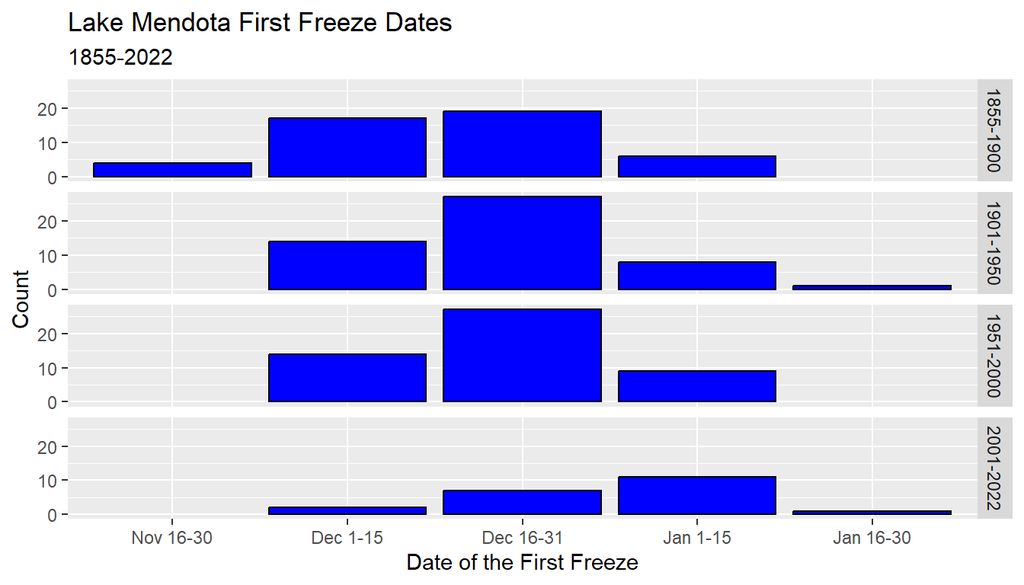

```r
ggplot(mendota, aes(x = ff_period)) +
  geom_bar(color = "black", fill = "blue") +
  xlab("Date of the First Freeze") +
  ylab("Count") +
  ggtitle("Lake Mendota First Freeze Dates",
          subtitle = "1855-2022") +
  facet_grid(rows = vars(period50))
```

- Here, the output uses a different column for each value of `period50`.
- The axis labels might get crowded!

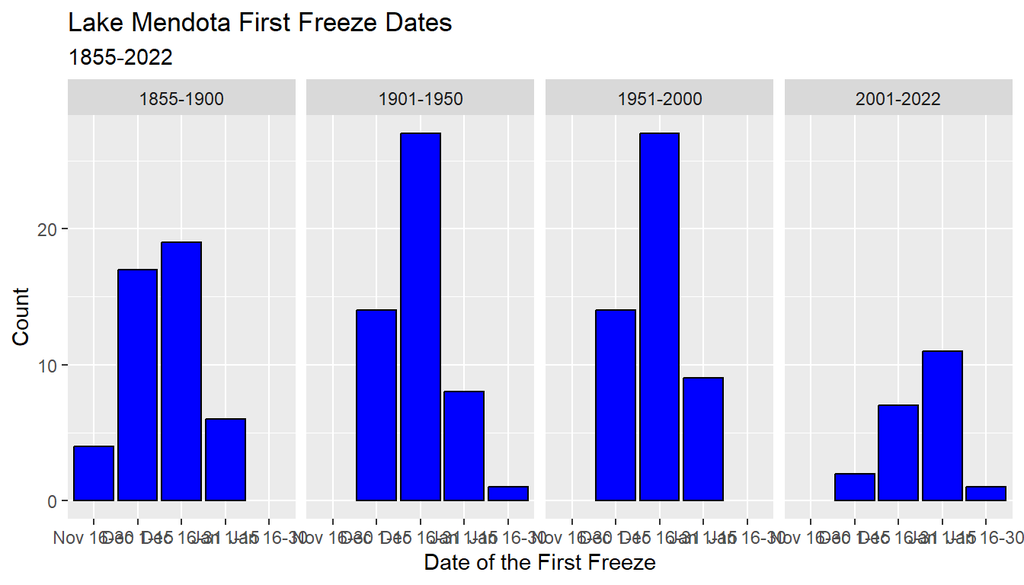

```r
ggplot(mendota, aes(x = ff_period)) +
  geom_bar(color = "black", fill = "blue") +
  xlab("Date of the First Freeze") +
  ylab("Count") +
  ggtitle("Lake Mendota First Freeze Dates",
          subtitle = "1855-2022") +
  facet_grid(cols = vars(period50))
```

- For a single variable, `facet_wrap()` usually is preferable.
- For a different data set where breaking up by two different categorical variables, `facet_grid()` can be very useful.
- You can see more examples at the [tidyverse reference page for `facet_grid()`](https://ggplot2.tidyverse.org/reference/facet_grid.html)